# Netflix Data Analysis and Visualization Project

## Recommendation System

**Method:**

- Used **CountVectorizer** to encode genres into a matrix.
- Calculated **cosine similarity** between all titles.
- Created a function `recommend(title)` to suggest top 5 similar titles.

```python
recommended = recommend('Breaking Bad')
print("Top 5 Recommendations:\n")
for title in recommended:
    print("-", title)
```

```
Top 5 Recommendations:

- Dare Me
- The Blacklist
- Ozark
- Designated Survivor
- Breaking Bad
```

```python
import plotly.express as px

if isinstance(recommended, pd.Series):
    titles = recommended.values
    df_reco = pd.DataFrame({
        'Title': titles,
        'Score': [5, 4, 3, 2, 1]
    })

    fig = px.bar(df_reco,
                 x='Score',
                 y='Title',
                 orientation='h',
                 text='Title',
                 color='Score',
                 color_continuous_scale='OrRd',
                 title="🎬 Top 5 Netflix Recommendations for 'Breaking Bad'")

    fig.update_layout(
        yaxis=dict(autorange='reversed'),
        showlegend=False
    )
    fig.show()
else:
    print(recommended)
```

[output not shown]

Violin Plot: Content Age by Type

[figure not shown]

```python
sns.violinplot(data=df, x='type', y='content_age', hue='type', palette='Reds', legend=False)

plt.title('Content Age Distribution by Type')
plt.show()
```

```python
print(df.columns.tolist())
```

[output not shown]

```python
for col in df.columns:
    print(f"'{col}'")
```

[output not shown]

```python
df.columns = df.columns.str.strip()  # Removes any spaces from all column names
```

Ratings Distribution

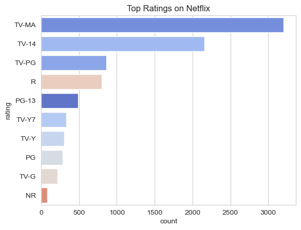

```python
sns.countplot(data=df, y='rating', hue='rating',
              order=df['rating'].value_counts().index[:10],
              palette='coolwarm', legend=False)
plt.title("Top Ratings on Netflix")
```

Country Analysis

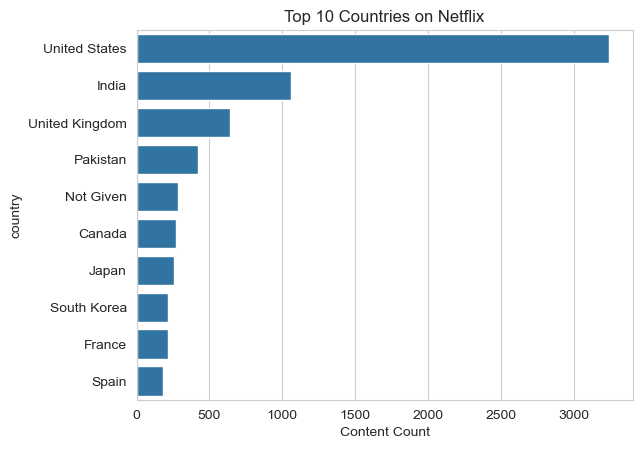

```python
top_countries = df['country'].value_counts().head(10)
sns.barplot(x=top_countries.values, y=top_countries.index)
plt.title("Top 10 Countries on Netflix"); plt.xlabel("Content Count"); plt.show()
```

Director Analysis and Insights

```python
print(df.columns.tolist())
```

```
['show_id', 'type', 'title', 'director', 'country', 'date_added', 'release_year', 'rating', 'duration', 'listed_in', 'content_age', 'duration_mins', 'year_added', 'month_added', 'genre_count']
```

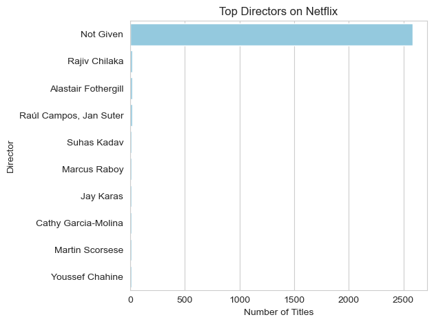

```python
top_directors = df[df['director'] != "Unknown"]['director'].value_counts().head(10)

sns.barplot(x=top_directors.values, y=top_directors.index, color='skyblue')
plt.title("Top Directors on Netflix")
plt.xlabel("Number of Titles"); plt.ylabel("Director")
plt.tight_layout(); plt.show()
```

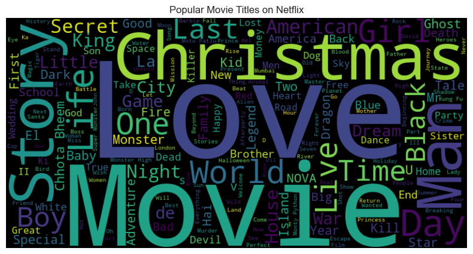

```python
titles = ' '.join(df[df['type'] == 'Movie']['title'].dropna())
wordcloud = WordCloud(background_color='black', width=800, height=400).generate(titles)

plt.figure(figsize=(10,5))
plt.imshow(wordcloud, interpolation='bilinear')
plt.axis('off'); plt.title("Popular Movie Titles on Netflix"); plt.show()
```

```python
print(df.head())
```

```
  show_id     type                             title         director  \
0      s1    Movie              Dick Johnson Is Dead  Kirsten Johnson
1      s3  TV Show                         Ganglands  Julien Leclercq
2      s6  TV Show                     Midnight Mass    Mike Flanagan
3     s14    Movie  Confessions of an Invisible Girl    Bruno Garotti
4      s8    Movie                           Sankofa     Haile Gerima

         country date_added  release_year rating  duration  \
0  United States 2021-09-25          2020  PG-13    90 min
1         France 2021-09-24          2021  TV-MA  1 Season
2  United States 2021-09-24          2021  TV-MA  1 Season
3         Brazil 2021-09-22          2021  TV-PG    91 min
4  United States 2021-09-24          1993  TV-MA   125 min

                                           listed_in  content_age  \
0                                      Documentaries            5
1  Crime TV Shows, International TV Shows, TV Act...            4
2                 TV Dramas, TV Horror, TV Mysteries            4
3                 Children & Family Movies, Comedies            4
4   Dramas, Independent Movies, International Movies           32

   duration_mins  year_added  month_added  genre_count
0           90.0        2021            9            1
1            1.0        2021            9            3
2            1.0        2021            9            3
3           91.0        2021            9            2
4          125.0        2021            9            3
```

## Conclusion

This project successfully:

1. **Cleaned and preprocessed** Netflix’s dataset.
2. **Engineered features** to enable deeper analysis.
3. Created **informative visualizations** highlighting trends in content type, genre, release timing, ratings, and contributors.
4. Developed a **basic recommendation engine** based on content similarity.

**Key Insights:**

- Netflix has a strong preference for certain genres and countries.
- Seasonal trends exist in content addition.
- Random forests or advanced ML could enhance the recommendation system in the future.